# 虚時間発展法によるGross-Pitaevskii方程式の定常解

トラップされた凝縮体のソリトン解を求める. 木谷さんの卒論を参考にしてます.

## 小話

かつて山中研でGP方程式の定常解を求める方法といえば「虚時間発展法をCrank-Nicolson法とGauss-Seidel法で解く」というのが一般的だった. というより, 一般の偏微分方程式の解法ではこれが最もベーシックな方法. これを持ち込んだのは当時B4の中村さん. とはいえ我々が扱うのはHamilton力学系なのでこんなに頑張って差分化せんでもSymplectic法でよくね？というのが現在の山中研のトレンドである.

Crank-Nicolson + Gauss-Seidelは過去の遺物として葬り去りたいのが本音. もちろんこっちのが良い場合も時にはあるだろうが...

```python
#Jupyter(iPython Notebook)のおまじない. 普段は書かないで良い.
%matplotlib inline

# coding: utf-8

import numpy as np
from scipy.integrate import simps
from scipy.fftpack import fft
from scipy.fftpack import ifft
from scipy.fftpack import fftfreq
import matplotlib.pyplot as plt
import seaborn as sbn
```

TDSE+TDGPの章で説明したものは省略.

### `scipy.integrate.simps()`

`scipy.integrate.quad()`と違い, 引数に`iterable`を取れる. 関数を離散化した後に積分したい時に.

### `matplotlib`

`Python`のグラフツール.

### `seaborn`

`matplotlib`の化粧箱. 見目を麗しくしてくれます. importするだけできれいになります. これ自体にも色々な機能があるっぽいですが今回は省略. ふつーのグラフしか書かないので.

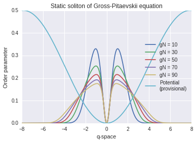

```python
# --*-- Set functions --*--

# Set initial function
def Psi_0(x):
    return x*np.exp(-x**2/2)

# Set potential
def V(x):
    return 25*np.sin(x/5)**2


# --*-- Set constants and variables for initial condition --*--

# Volume, Maximum x-step
L, xN = 16.0, 1024

# Interaction constant, Chemical potential
gN, mu = 50, 10

# Maximum time, Time step
tMax, tN = 2, 256

# x-step, Time step
h, dt = L/xN, tMax/tN

# Set x-space
x = np.linspace(-L/2, L/2, xN)

# Set time propagator of poptential term except nonlinear term
pre_expV = np.exp((mu - V(x))*dt)


# --*-- Time propagation by symplectic numerical solution --*--

# For-loop on each value of gN
for gN in [10, 30, 50, 70, 90]:
    # Set operators for time propagation for every gNs
    arr_Psi = Psi_0(x)
    expV = np.exp((-gN*Psi_0(x)**2)*dt)*pre_expV
    expK = np.exp(-(2*np.pi*fftfreq(xN, d=1/xN)/L)**2*dt)

    # Time propagation
    for i in range(tN):
        # Multipling by time propagator of potential term
        arr_Psi = arr_Psi*expV

        # Fourier transformation
        arr_Psi = fft(arr_Psi)

        # Multipling time propagator of kinetic term
        arr_Psi *= expK

        # Inverse fourier transformation
        arr_Psi = ifft(arr_Psi)

        # Correction of chemical potential mu
        mu -= (simps(arr_Psi**2, x) - 1)/(2*dt)

        # Normalization of order parameter arr_Psi
        arr_Psi /= np.sqrt(simps(np.real(arr_Psi**2), x))

        # Reconfigure expV
        expV = np.exp((-gN*arr_Psi**2)*dt)*pre_expV

    # Plot arr_Psi for present gN
    plt.plot(x, np.real(arr_Psi**2), label="gN = {0}".format(gN))

# Matplotlib configuration
plt.plot(x, V(x)/50, label="Potential\n(provisional)")
plt.ylim(0, 0.5)
plt.xlabel("q-space")
plt.ylabel("Order parameter")
plt.title("Static soliton of Gross-Pitaevskii equation")
plt.legend(loc = 'center right')
plt.show()
```

あとはもうほぼ前回と同じなので大丈夫でしょう. 今回は化学ポテンシャルの補正を時間発展ごとに加えなければなりません. 粒子数が保存しなければいけないので $$ N = \int dx\ |\xi(x, t)|^2 $$ を満たさなければなりません. そんなわけで虚時間GP方程式の左から秩序変数の複素共役をかけて積分したとき, $$ i\int dx |\xi(x, t)|^2 = iN = \int dx[\xi^*\partial_x^2\xi + \mu|\xi|^2 - V(x)|\xi|^2 - gN|\xi|^4] $$ を満たすように化学ポテンシャルを決める必要があります. このお話の詳細は木谷さんの卒論を参考にしてください.